# Risk Factor Analysis

## Outcome Variable

**Outcome Variable:** wast_rec90d

## Predictor Variables

**Intervention Variable:** nchldlt5

**Adjustment Set:**

- arm
- W_mage
- meducyrs
- feducyrs
- hhwealth_quart
- hfoodsec
- W_mhtcm
- W_mwtkg
- W_mbmi
- W_nrooms
- W_parity
- impfloor
- impsan
- safeh20
- delta_W_mage
- delta_meducyrs
- delta_feducyrs
- delta_hhwealth_quart
- delta_hfoodsec
- delta_W_mhtcm
- delta_W_mwtkg
- delta_W_mbmi
- delta_W_nrooms
- delta_W_parity
- delta_impfloor
- delta_impsan
- delta_safeh20

## Stratifying Variables

The analysis was stratified on these variable(s):

- agecat
- studyid
- country

## Data Summary

| agecat | studyid | country | nchldlt5 | wast_rec90d | n_cell | n |
| --- | --- | --- | --- | --- | --- | --- |
| 0-24 months | ki1000108-IRC | INDIA | 1 | 0 | 39 | 395 |
| 0-24 months | ki1000108-IRC | INDIA | 1 | 1 | 56 | 395 |
| 0-24 months | ki1000108-IRC | INDIA | 2+ | 0 | 123 | 395 |
| 0-24 months | ki1000108-IRC | INDIA | 2+ | 1 | 177 | 395 |
| 0-24 months | ki1017093b-PROVIDE | BANGLADESH | 1 | 0 | 87 | 308 |
| 0-24 months | ki1017093b-PROVIDE | BANGLADESH | 1 | 1 | 138 | 308 |
| 0-24 months | ki1017093b-PROVIDE | BANGLADESH | 2+ | 0 | 42 | 308 |
| 0-24 months | ki1017093b-PROVIDE | BANGLADESH | 2+ | 1 | 41 | 308 |
| 0-24 months | ki1017093c-NIH-Crypto | BANGLADESH | 1 | 0 | 73 | 310 |
| 0-24 months | ki1017093c-NIH-Crypto | BANGLADESH | 1 | 1 | 136 | 310 |
| 0-24 months | ki1017093c-NIH-Crypto | BANGLADESH | 2+ | 0 | 44 | 310 |
| 0-24 months | ki1017093c-NIH-Crypto | BANGLADESH | 2+ | 1 | 57 | 310 |
| 0-24 months | ki1066203-TanzaniaChild2 | TANZANIA, UNITED REPUBLIC OF | 1 | 0 | 186 | 711 |
| 0-24 months | ki1066203-TanzaniaChild2 | TANZANIA, UNITED REPUBLIC OF | 1 | 1 | 315 | 711 |
| 0-24 months | ki1066203-TanzaniaChild2 | TANZANIA, UNITED REPUBLIC OF | 2+ | 0 | 80 | 711 |
| 0-24 months | ki1066203-TanzaniaChild2 | TANZANIA, UNITED REPUBLIC OF | 2+ | 1 | 130 | 711 |
| 0-24 months | ki1112895-iLiNS-Zinc | BURKINA FASO | 1 | 0 | 241 | 787 |
| 0-24 months | ki1112895-iLiNS-Zinc | BURKINA FASO | 1 | 1 | 10 | 787 |
| 0-24 months | ki1112895-iLiNS-Zinc | BURKINA FASO | 2+ | 0 | 512 | 787 |
| 0-24 months | ki1112895-iLiNS-Zinc | BURKINA FASO | 2+ | 1 | 24 | 787 |
| 0-24 months | ki1148112-LCNI-5 | MALAWI | 1 | 0 | 25 | 78 |
| 0-24 months | ki1148112-LCNI-5 | MALAWI | 1 | 1 | 6 | 78 |
| 0-24 months | ki1148112-LCNI-5 | MALAWI | 2+ | 0 | 40 | 78 |
| 0-24 months | ki1148112-LCNI-5 | MALAWI | 2+ | 1 | 7 | 78 |
| 0-24 months | kiGH5241-JiVitA-3 | BANGLADESH | 1 | 0 | 2739 | 7562 |
| 0-24 months | kiGH5241-JiVitA-3 | BANGLADESH | 1 | 1 | 2148 | 7562 |
| 0-24 months | kiGH5241-JiVitA-3 | BANGLADESH | 2+ | 0 | 1629 | 7562 |
| 0-24 months | kiGH5241-JiVitA-3 | BANGLADESH | 2+ | 1 | 1046 | 7562 |
| 0-6 months | ki1000108-IRC | INDIA | 1 | 0 | 20 | 240 |
| 0-6 months | ki1000108-IRC | INDIA | 1 | 1 | 37 | 240 |
| 0-6 months | ki1000108-IRC | INDIA | 2+ | 0 | 67 | 240 |
| 0-6 months | ki1000108-IRC | INDIA | 2+ | 1 | 116 | 240 |
| 0-6 months | ki1017093b-PROVIDE | BANGLADESH | 1 | 0 | 25 | 185 |
| 0-6 months | ki1017093b-PROVIDE | BANGLADESH | 1 | 1 | 115 | 185 |
| 0-6 months | ki1017093b-PROVIDE | BANGLADESH | 2+ | 0 | 15 | 185 |
| 0-6 months | ki1017093b-PROVIDE | BANGLADESH | 2+ | 1 | 30 | 185 |
| 0-6 months | ki1017093c-NIH-Crypto | BANGLADESH | 1 | 0 | 14 | 197 |
| 0-6 months | ki1017093c-NIH-Crypto | BANGLADESH | 1 | 1 | 124 | 197 |
| 0-6 months | ki1017093c-NIH-Crypto | BANGLADESH | 2+ | 0 | 7 | 197 |
| 0-6 months | ki1017093c-NIH-Crypto | BANGLADESH | 2+ | 1 | 52 | 197 |
| 0-6 months | ki1066203-TanzaniaChild2 | TANZANIA, UNITED REPUBLIC OF | 1 | 0 | 66 | 339 |
| 0-6 months | ki1066203-TanzaniaChild2 | TANZANIA, UNITED REPUBLIC OF | 1 | 1 | 170 | 339 |
| 0-6 months | ki1066203-TanzaniaChild2 | TANZANIA, UNITED REPUBLIC OF | 2+ | 0 | 35 | 339 |
| 0-6 months | ki1066203-TanzaniaChild2 | TANZANIA, UNITED REPUBLIC OF | 2+ | 1 | 68 | 339 |
| 0-6 months | ki1148112-LCNI-5 | MALAWI | 1 | 0 | 1 | 4 |
| 0-6 months | ki1148112-LCNI-5 | MALAWI | 1 | 1 | 0 | 4 |
| 0-6 months | ki1148112-LCNI-5 | MALAWI | 2+ | 0 | 3 | 4 |
| 0-6 months | ki1148112-LCNI-5 | MALAWI | 2+ | 1 | 0 | 4 |
| 0-6 months | kiGH5241-JiVitA-3 | BANGLADESH | 1 | 0 | 952 | 4730 |
| 0-6 months | kiGH5241-JiVitA-3 | BANGLADESH | 1 | 1 | 2148 | 4730 |
| 0-6 months | kiGH5241-JiVitA-3 | BANGLADESH | 2+ | 0 | 584 | 4730 |
| 0-6 months | kiGH5241-JiVitA-3 | BANGLADESH | 2+ | 1 | 1046 | 4730 |
| 6-24 months | ki1000108-IRC | INDIA | 1 | 0 | 19 | 155 |
| 6-24 months | ki1000108-IRC | INDIA | 1 | 1 | 19 | 155 |
| 6-24 months | ki1000108-IRC | INDIA | 2+ | 0 | 56 | 155 |
| 6-24 months | ki1000108-IRC | INDIA | 2+ | 1 | 61 | 155 |
| 6-24 months | ki1017093b-PROVIDE | BANGLADESH | 1 | 0 | 62 | 123 |
| 6-24 months | ki1017093b-PROVIDE | BANGLADESH | 1 | 1 | 23 | 123 |
| 6-24 months | ki1017093b-PROVIDE | BANGLADESH | 2+ | 0 | 27 | 123 |
| 6-24 months | ki1017093b-PROVIDE | BANGLADESH | 2+ | 1 | 11 | 123 |
| 6-24 months | ki1017093c-NIH-Crypto | BANGLADESH | 1 | 0 | 59 | 113 |
| 6-24 months | ki1017093c-NIH-Crypto | BANGLADESH | 1 | 1 | 12 | 113 |
| 6-24 months | ki1017093c-NIH-Crypto | BANGLADESH | 2+ | 0 | 37 | 113 |
| 6-24 months | ki1017093c-NIH-Crypto | BANGLADESH | 2+ | 1 | 5 | 113 |
| 6-24 months | ki1066203-TanzaniaChild2 | TANZANIA, UNITED REPUBLIC OF | 1 | 0 | 120 | 372 |
| 6-24 months | ki1066203-TanzaniaChild2 | TANZANIA, UNITED REPUBLIC OF | 1 | 1 | 145 | 372 |
| 6-24 months | ki1066203-TanzaniaChild2 | TANZANIA, UNITED REPUBLIC OF | 2+ | 0 | 45 | 372 |
| 6-24 months | ki1066203-TanzaniaChild2 | TANZANIA, UNITED REPUBLIC OF | 2+ | 1 | 62 | 372 |
| 6-24 months | ki1112895-iLiNS-Zinc | BURKINA FASO | 1 | 0 | 241 | 787 |
| 6-24 months | ki1112895-iLiNS-Zinc | BURKINA FASO | 1 | 1 | 10 | 787 |
| 6-24 months | ki1112895-iLiNS-Zinc | BURKINA FASO | 2+ | 0 | 512 | 787 |
| 6-24 months | ki1112895-iLiNS-Zinc | BURKINA FASO | 2+ | 1 | 24 | 787 |
| 6-24 months | ki1148112-LCNI-5 | MALAWI | 1 | 0 | 24 | 74 |
| 6-24 months | ki1148112-LCNI-5 | MALAWI | 1 | 1 | 6 | 74 |
| 6-24 months | ki1148112-LCNI-5 | MALAWI | 2+ | 0 | 37 | 74 |
| 6-24 months | ki1148112-LCNI-5 | MALAWI | 2+ | 1 | 7 | 74 |
| 6-24 months | kiGH5241-JiVitA-3 | BANGLADESH | 1 | 0 | 1787 | 2832 |
| 6-24 months | kiGH5241-JiVitA-3 | BANGLADESH | 1 | 1 | 0 | 2832 |
| 6-24 months | kiGH5241-JiVitA-3 | BANGLADESH | 2+ | 0 | 1045 | 2832 |
| 6-24 months | kiGH5241-JiVitA-3 | BANGLADESH | 2+ | 1 | 0 | 2832 |

The following strata were considered:

- agecat: 0-24 months, studyid: ki1000108-IRC, country: INDIA
- agecat: 0-24 months, studyid: ki1017093b-PROVIDE, country: BANGLADESH
- agecat: 0-24 months, studyid: ki1017093c-NIH-Crypto, country: BANGLADESH
- agecat: 0-24 months, studyid: ki1066203-TanzaniaChild2, country: TANZANIA, UNITED REPUBLIC OF
- agecat: 0-24 months, studyid: ki1112895-iLiNS-Zinc, country: BURKINA FASO
- agecat: 0-24 months, studyid: ki1148112-LCNI-5, country: MALAWI
- agecat: 0-24 months, studyid: kiGH5241-JiVitA-3, country: BANGLADESH
- agecat: 0-6 months, studyid: ki1000108-IRC, country: INDIA
- agecat: 0-6 months, studyid: ki1017093b-PROVIDE, country: BANGLADESH
- agecat: 0-6 months, studyid: ki1017093c-NIH-Crypto, country: BANGLADESH
- agecat: 0-6 months, studyid: ki1066203-TanzaniaChild2, country: TANZANIA, UNITED REPUBLIC OF
- agecat: 0-6 months, studyid: ki1148112-LCNI-5, country: MALAWI
- agecat: 0-6 months, studyid: kiGH5241-JiVitA-3, country: BANGLADESH
- agecat: 6-24 months, studyid: ki1000108-IRC, country: INDIA
- agecat: 6-24 months, studyid: ki1017093b-PROVIDE, country: BANGLADESH
- agecat: 6-24 months, studyid: ki1017093c-NIH-Crypto, country: BANGLADESH
- agecat: 6-24 months, studyid: ki1066203-TanzaniaChild2, country: TANZANIA, UNITED REPUBLIC OF
- agecat: 6-24 months, studyid: ki1112895-iLiNS-Zinc, country: BURKINA FASO
- agecat: 6-24 months, studyid: ki1148112-LCNI-5, country: MALAWI
- agecat: 6-24 months, studyid: kiGH5241-JiVitA-3, country: BANGLADESH

### Dropped Strata

Some strata were dropped due to rare outcomes:

- agecat: 0-6 months, studyid: ki1148112-LCNI-5, country: MALAWI
- agecat: 6-24 months, studyid: kiGH5241-JiVitA-3, country: BANGLADESH

## Methods Detail

We’re interested in the causal parameters $E[Y_a]$ for all values of $a \in \mathcal{A}$. These parameters represent the mean outcome if, possibly contrary to fact, we intervened to set all units to have $A=a$. Under the randomization and positivity assumptions, these are identified by the statistical parameters $\psi_a=E_W[E_{Y|A,W}(Y|A=a,W)]$. In addition, we’re interested in the mean of $Y$, $E[Y]$ under no intervention (the observed mean). We will estimate these parameters by using SuperLearner to fit the relevant likelihood factors – $E_{Y|A,W}(Y|A=a,W)$ and $p(A=a|W)$, and then updating our likelihood fit using a joint TMLE.

For unadjusted analyses ($W=\{\}$), initial likelihoods were estimated using Lrnr_glm to estimate the simple $E(Y|A)$ and Lrnr_mean to estimate $p(A)$. For adjusted analyses, a small library containing Lrnr_glmnet, Lrnr_xgboost, and Lrnr_mean was used.

Having estimated these parameters, we will then use the delta method to estimate relative risks and attributable risks relative to a prespecified baseline level of $A$.

# Results Detail

## Results Plots

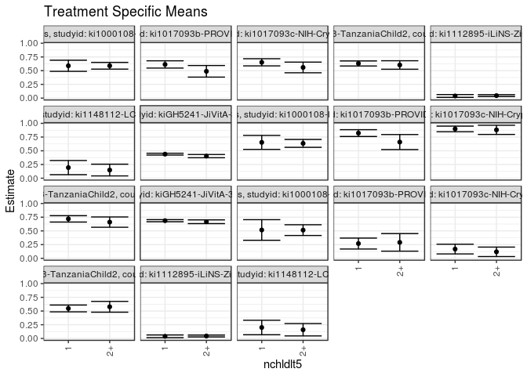

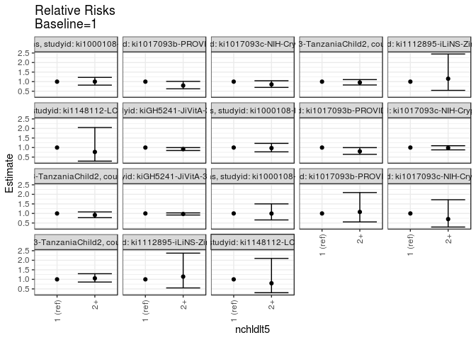

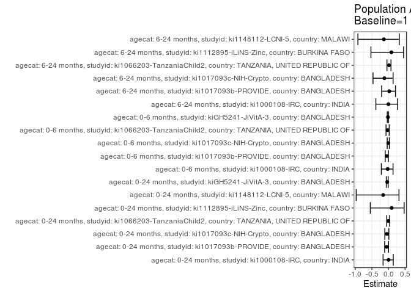

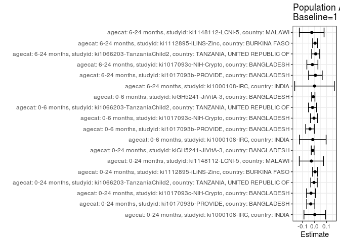

## Results Table

### Parameter: TSM

| agecat | studyid | country | intervention_level | baseline_level | estimate | ci_lower | ci_upper |
| --- | --- | --- | --- | --- | --- | --- | --- |
| 0-24 months | ki1000108-IRC | INDIA | 1 | NA | 0.5887303 | 0.4871651 | 0.6902956 |
| 0-24 months | ki1000108-IRC | INDIA | 2+ | NA | 0.5893458 | 0.5283509 | 0.6503408 |
| 0-24 months | ki1017093b-PROVIDE | BANGLADESH | 1 | NA | 0.6132107 | 0.5468907 | 0.6795306 |
| 0-24 months | ki1017093b-PROVIDE | BANGLADESH | 2+ | NA | 0.4880442 | 0.3823893 | 0.5936990 |
| 0-24 months | ki1017093c-NIH-Crypto | BANGLADESH | 1 | NA | 0.6523553 | 0.5871684 | 0.7175422 |
| 0-24 months | ki1017093c-NIH-Crypto | BANGLADESH | 2+ | NA | 0.5585556 | 0.4613967 | 0.6557145 |
| 0-24 months | ki1066203-TanzaniaChild2 | TANZANIA, UNITED REPUBLIC OF | 1 | NA | 0.6309066 | 0.5848526 | 0.6769606 |
| 0-24 months | ki1066203-TanzaniaChild2 | TANZANIA, UNITED REPUBLIC OF | 2+ | NA | 0.6031388 | 0.5262061 | 0.6800715 |
| 0-24 months | ki1112895-iLiNS-Zinc | BURKINA FASO | 1 | NA | 0.0390870 | 0.0136659 | 0.0645081 |
| 0-24 months | ki1112895-iLiNS-Zinc | BURKINA FASO | 2+ | NA | 0.0450923 | 0.0278938 | 0.0622908 |
| 0-24 months | ki1148112-LCNI-5 | MALAWI | 1 | NA | 0.1935484 | 0.0643859 | 0.3227109 |
| 0-24 months | ki1148112-LCNI-5 | MALAWI | 2+ | NA | 0.1489362 | 0.0421700 | 0.2557024 |
| 0-24 months | kiGH5241-JiVitA-3 | BANGLADESH | 1 | NA | 0.4384564 | 0.4219503 | 0.4549625 |
| 0-24 months | kiGH5241-JiVitA-3 | BANGLADESH | 2+ | NA | 0.4026046 | 0.3729430 | 0.4322663 |
| 0-6 months | ki1000108-IRC | INDIA | 1 | NA | 0.6530148 | 0.5255944 | 0.7804351 |
| 0-6 months | ki1000108-IRC | INDIA | 2+ | NA | 0.6348632 | 0.5630025 | 0.7067238 |
| 0-6 months | ki1017093b-PROVIDE | BANGLADESH | 1 | NA | 0.8223390 | 0.7602676 | 0.8844104 |
| 0-6 months | ki1017093b-PROVIDE | BANGLADESH | 2+ | NA | 0.6591050 | 0.5220941 | 0.7961158 |
| 0-6 months | ki1017093c-NIH-Crypto | BANGLADESH | 1 | NA | 0.8985507 | 0.8475715 | 0.9495299 |
| 0-6 months | ki1017093c-NIH-Crypto | BANGLADESH | 2+ | NA | 0.8813559 | 0.7977824 | 0.9649295 |
| 0-6 months | ki1066203-TanzaniaChild2 | TANZANIA, UNITED REPUBLIC OF | 1 | NA | 0.7195847 | 0.6614546 | 0.7777147 |
| 0-6 months | ki1066203-TanzaniaChild2 | TANZANIA, UNITED REPUBLIC OF | 2+ | NA | 0.6604089 | 0.5665714 | 0.7542464 |
| 0-6 months | kiGH5241-JiVitA-3 | BANGLADESH | 1 | NA | 0.6862888 | 0.6671141 | 0.7054635 |
| 0-6 months | kiGH5241-JiVitA-3 | BANGLADESH | 2+ | NA | 0.6669651 | 0.6328298 | 0.7011004 |
| 6-24 months | ki1000108-IRC | INDIA | 1 | NA | 0.5169552 | 0.3293268 | 0.7045836 |
| 6-24 months | ki1000108-IRC | INDIA | 2+ | NA | 0.5144176 | 0.4165970 | 0.6122382 |
| 6-24 months | ki1017093b-PROVIDE | BANGLADESH | 1 | NA | 0.2697028 | 0.1701232 | 0.3692823 |
| 6-24 months | ki1017093b-PROVIDE | BANGLADESH | 2+ | NA | 0.2909997 | 0.1309182 | 0.4510813 |
| 6-24 months | ki1017093c-NIH-Crypto | BANGLADESH | 1 | NA | 0.1690141 | 0.0805585 | 0.2574696 |
| 6-24 months | ki1017093c-NIH-Crypto | BANGLADESH | 2+ | NA | 0.1190476 | 0.0331409 | 0.2049543 |
| 6-24 months | ki1066203-TanzaniaChild2 | TANZANIA, UNITED REPUBLIC OF | 1 | NA | 0.5474915 | 0.4855659 | 0.6094170 |
| 6-24 months | ki1066203-TanzaniaChild2 | TANZANIA, UNITED REPUBLIC OF | 2+ | NA | 0.5774980 | 0.4790495 | 0.6759465 |
| 6-24 months | ki1112895-iLiNS-Zinc | BURKINA FASO | 1 | NA | 0.0394373 | 0.0147525 | 0.0641221 |
| 6-24 months | ki1112895-iLiNS-Zinc | BURKINA FASO | 2+ | NA | 0.0450806 | 0.0280059 | 0.0621553 |
| 6-24 months | ki1148112-LCNI-5 | MALAWI | 1 | NA | 0.2000000 | 0.0680734 | 0.3319266 |
| 6-24 months | ki1148112-LCNI-5 | MALAWI | 2+ | NA | 0.1590909 | 0.0462498 | 0.2719320 |

### Parameter: E(Y)

| agecat | studyid | country | intervention_level | baseline_level | estimate | ci_lower | ci_upper |
| --- | --- | --- | --- | --- | --- | --- | --- |
| 0-24 months | ki1000108-IRC | INDIA | NA | NA | 0.5898734 | 0.5376978 | 0.6420491 |
| 0-24 months | ki1017093b-PROVIDE | BANGLADESH | NA | NA | 0.5811688 | 0.5245443 | 0.6377934 |
| 0-24 months | ki1017093c-NIH-Crypto | BANGLADESH | NA | NA | 0.6225806 | 0.5684562 | 0.6767051 |
| 0-24 months | ki1066203-TanzaniaChild2 | TANZANIA, UNITED REPUBLIC OF | NA | NA | 0.6258790 | 0.5881498 | 0.6636083 |
| 0-24 months | ki1112895-iLiNS-Zinc | BURKINA FASO | NA | NA | 0.0432020 | 0.0290622 | 0.0573419 |
| 0-24 months | ki1148112-LCNI-5 | MALAWI | NA | NA | 0.1666667 | 0.0842830 | 0.2490503 |
| 0-24 months | kiGH5241-JiVitA-3 | BANGLADESH | NA | NA | 0.4223750 | 0.4112475 | 0.4335026 |
| 0-6 months | ki1000108-IRC | INDIA | NA | NA | 0.6375000 | 0.5751450 | 0.6998550 |
| 0-6 months | ki1017093b-PROVIDE | BANGLADESH | NA | NA | 0.7837838 | 0.7252863 | 0.8422812 |
| 0-6 months | ki1017093c-NIH-Crypto | BANGLADESH | NA | NA | 0.8934010 | 0.8497799 | 0.9370221 |
| 0-6 months | ki1066203-TanzaniaChild2 | TANZANIA, UNITED REPUBLIC OF | NA | NA | 0.7020649 | 0.6526590 | 0.7514708 |
| 0-6 months | kiGH5241-JiVitA-3 | BANGLADESH | NA | NA | 0.6752643 | 0.6619190 | 0.6886095 |
| 6-24 months | ki1000108-IRC | INDIA | NA | NA | 0.5161290 | 0.4322562 | 0.6000019 |
| 6-24 months | ki1017093b-PROVIDE | BANGLADESH | NA | NA | 0.2764228 | 0.1950773 | 0.3577682 |
| 6-24 months | ki1017093c-NIH-Crypto | BANGLADESH | NA | NA | 0.1504425 | 0.0860251 | 0.2148599 |
| 6-24 months | ki1066203-TanzaniaChild2 | TANZANIA, UNITED REPUBLIC OF | NA | NA | 0.5564516 | 0.5041613 | 0.6087419 |
| 6-24 months | ki1112895-iLiNS-Zinc | BURKINA FASO | NA | NA | 0.0432020 | 0.0290622 | 0.0573419 |
| 6-24 months | ki1148112-LCNI-5 | MALAWI | NA | NA | 0.1756757 | 0.0897916 | 0.2615597 |

### Parameter: RR

| agecat | studyid | country | intervention_level | baseline_level | estimate | ci_lower | ci_upper |
| --- | --- | --- | --- | --- | --- | --- | --- |
| 0-24 months | ki1000108-IRC | INDIA | 1 | 1 | 1.0000000 | 1.0000000 | 1.0000000 |
| 0-24 months | ki1000108-IRC | INDIA | 2+ | 1 | 1.0010454 | 0.8184631 | 1.2243581 |
| 0-24 months | ki1017093b-PROVIDE | BANGLADESH | 1 | 1 | 1.0000000 | 1.0000000 | 1.0000000 |
| 0-24 months | ki1017093b-PROVIDE | BANGLADESH | 2+ | 1 | 0.7958834 | 0.6248156 | 1.0137876 |
| 0-24 months | ki1017093c-NIH-Crypto | BANGLADESH | 1 | 1 | 1.0000000 | 1.0000000 | 1.0000000 |
| 0-24 months | ki1017093c-NIH-Crypto | BANGLADESH | 2+ | 1 | 0.8562137 | 0.7001899 | 1.0470044 |
| 0-24 months | ki1066203-TanzaniaChild2 | TANZANIA, UNITED REPUBLIC OF | 1 | 1 | 1.0000000 | 1.0000000 | 1.0000000 |
| 0-24 months | ki1066203-TanzaniaChild2 | TANZANIA, UNITED REPUBLIC OF | 2+ | 1 | 0.9559875 | 0.8253225 | 1.1073393 |
| 0-24 months | ki1112895-iLiNS-Zinc | BURKINA FASO | 1 | 1 | 1.0000000 | 1.0000000 | 1.0000000 |
| 0-24 months | ki1112895-iLiNS-Zinc | BURKINA FASO | 2+ | 1 | 1.1536405 | 0.5436388 | 2.4481081 |
| 0-24 months | ki1148112-LCNI-5 | MALAWI | 1 | 1 | 1.0000000 | 1.0000000 | 1.0000000 |
| 0-24 months | ki1148112-LCNI-5 | MALAWI | 2+ | 1 | 0.7695035 | 0.2889550 | 2.0492314 |
| 0-24 months | kiGH5241-JiVitA-3 | BANGLADESH | 1 | 1 | 1.0000000 | 1.0000000 | 1.0000000 |
| 0-24 months | kiGH5241-JiVitA-3 | BANGLADESH | 2+ | 1 | 0.9182319 | 0.8455624 | 0.9971468 |
| 0-6 months | ki1000108-IRC | INDIA | 1 | 1 | 1.0000000 | 1.0000000 | 1.0000000 |
| 0-6 months | ki1000108-IRC | INDIA | 2+ | 1 | 0.9722034 | 0.7756285 | 1.2185981 |
| 0-6 months | ki1017093b-PROVIDE | BANGLADESH | 1 | 1 | 1.0000000 | 1.0000000 | 1.0000000 |
| 0-6 months | ki1017093b-PROVIDE | BANGLADESH | 2+ | 1 | 0.8015003 | 0.6446637 | 0.9964928 |
| 0-6 months | ki1017093c-NIH-Crypto | BANGLADESH | 1 | 1 | 1.0000000 | 1.0000000 | 1.0000000 |
| 0-6 months | ki1017093c-NIH-Crypto | BANGLADESH | 2+ | 1 | 0.9808639 | 0.8782515 | 1.0954652 |
| 0-6 months | ki1066203-TanzaniaChild2 | TANZANIA, UNITED REPUBLIC OF | 1 | 1 | 1.0000000 | 1.0000000 | 1.0000000 |
| 0-6 months | ki1066203-TanzaniaChild2 | TANZANIA, UNITED REPUBLIC OF | 2+ | 1 | 0.9177640 | 0.7792006 | 1.0809679 |
| 0-6 months | kiGH5241-JiVitA-3 | BANGLADESH | 1 | 1 | 1.0000000 | 1.0000000 | 1.0000000 |
| 0-6 months | kiGH5241-JiVitA-3 | BANGLADESH | 2+ | 1 | 0.9718432 | 0.9170557 | 1.0299038 |
| 6-24 months | ki1000108-IRC | INDIA | 1 | 1 | 1.0000000 | 1.0000000 | 1.0000000 |
| 6-24 months | ki1000108-IRC | INDIA | 2+ | 1 | 0.9950913 | 0.6598265 | 1.5007078 |
| 6-24 months | ki1017093b-PROVIDE | BANGLADESH | 1 | 1 | 1.0000000 | 1.0000000 | 1.0000000 |
| 6-24 months | ki1017093b-PROVIDE | BANGLADESH | 2+ | 1 | 1.0789646 | 0.5558909 | 2.0942321 |
| 6-24 months | ki1017093c-NIH-Crypto | BANGLADESH | 1 | 1 | 1.0000000 | 1.0000000 | 1.0000000 |
| 6-24 months | ki1017093c-NIH-Crypto | BANGLADESH | 2+ | 1 | 0.7043651 | 0.2888063 | 1.7178646 |
| 6-24 months | ki1066203-TanzaniaChild2 | TANZANIA, UNITED REPUBLIC OF | 1 | 1 | 1.0000000 | 1.0000000 | 1.0000000 |
| 6-24 months | ki1066203-TanzaniaChild2 | TANZANIA, UNITED REPUBLIC OF | 2+ | 1 | 1.0548074 | 0.8594288 | 1.2946023 |
| 6-24 months | ki1112895-iLiNS-Zinc | BURKINA FASO | 1 | 1 | 1.0000000 | 1.0000000 | 1.0000000 |
| 6-24 months | ki1112895-iLiNS-Zinc | BURKINA FASO | 2+ | 1 | 1.1430952 | 0.5508518 | 2.3720838 |
| 6-24 months | ki1148112-LCNI-5 | MALAWI | 1 | 1 | 1.0000000 | 1.0000000 | 1.0000000 |
| 6-24 months | ki1148112-LCNI-5 | MALAWI | 2+ | 1 | 0.7954545 | 0.3019242 | 2.0957182 |

### Parameter: PAR

| agecat | studyid | country | intervention_level | baseline_level | estimate | ci_lower | ci_upper |
| --- | --- | --- | --- | --- | --- | --- | --- |
| 0-24 months | ki1000108-IRC | INDIA | 1 | NA | 0.0011431 | -0.0891202 | 0.0914063 |
| 0-24 months | ki1017093b-PROVIDE | BANGLADESH | 1 | NA | -0.0320418 | -0.0658770 | 0.0017934 |
| 0-24 months | ki1017093c-NIH-Crypto | BANGLADESH | 1 | NA | -0.0297747 | -0.0675183 | 0.0079689 |
| 0-24 months | ki1066203-TanzaniaChild2 | TANZANIA, UNITED REPUBLIC OF | 1 | NA | -0.0050276 | -0.0322970 | 0.0222419 |
| 0-24 months | ki1112895-iLiNS-Zinc | BURKINA FASO | 1 | NA | 0.0041150 | -0.0168127 | 0.0250428 |
| 0-24 months | ki1148112-LCNI-5 | MALAWI | 1 | NA | -0.0268817 | -0.1281436 | 0.0743802 |
| 0-24 months | kiGH5241-JiVitA-3 | BANGLADESH | 1 | NA | -0.0160813 | -0.0279512 | -0.0042115 |
| 0-6 months | ki1000108-IRC | INDIA | 1 | NA | -0.0155148 | -0.1274049 | 0.0963753 |
| 0-6 months | ki1017093b-PROVIDE | BANGLADESH | 1 | NA | -0.0385552 | -0.0747705 | -0.0023399 |
| 0-6 months | ki1017093c-NIH-Crypto | BANGLADESH | 1 | NA | -0.0051497 | -0.0344911 | 0.0241917 |
| 0-6 months | ki1066203-TanzaniaChild2 | TANZANIA, UNITED REPUBLIC OF | 1 | NA | -0.0175198 | -0.0512228 | 0.0161833 |
| 0-6 months | kiGH5241-JiVitA-3 | BANGLADESH | 1 | NA | -0.0110245 | -0.0247537 | 0.0027046 |
| 6-24 months | ki1000108-IRC | INDIA | 1 | NA | -0.0008262 | -0.1666029 | 0.1649506 |
| 6-24 months | ki1017093b-PROVIDE | BANGLADESH | 1 | NA | 0.0067200 | -0.0503482 | 0.0637882 |
| 6-24 months | ki1017093c-NIH-Crypto | BANGLADESH | 1 | NA | -0.0185716 | -0.0649036 | 0.0277604 |
| 6-24 months | ki1066203-TanzaniaChild2 | TANZANIA, UNITED REPUBLIC OF | 1 | NA | 0.0089601 | -0.0245888 | 0.0425091 |
| 6-24 months | ki1112895-iLiNS-Zinc | BURKINA FASO | 1 | NA | 0.0037647 | -0.0165405 | 0.0240699 |
| 6-24 months | ki1148112-LCNI-5 | MALAWI | 1 | NA | -0.0243243 | -0.1278155 | 0.0791669 |

### Parameter: PAF

| agecat | studyid | country | intervention_level | baseline_level | estimate | ci_lower | ci_upper |
| --- | --- | --- | --- | --- | --- | --- | --- |
| 0-24 months | ki1000108-IRC | INDIA | 1 | NA | 0.0019378 | -0.1634256 | 0.1437974 |
| 0-24 months | ki1017093b-PROVIDE | BANGLADESH | 1 | NA | -0.0551334 | -0.1151805 | 0.0016804 |
| 0-24 months | ki1017093c-NIH-Crypto | BANGLADESH | 1 | NA | -0.0478246 | -0.1105006 | 0.0113140 |
| 0-24 months | ki1066203-TanzaniaChild2 | TANZANIA, UNITED REPUBLIC OF | 1 | NA | -0.0080328 | -0.0525721 | 0.0346218 |
| 0-24 months | ki1112895-iLiNS-Zinc | BURKINA FASO | 1 | NA | 0.0952512 | -0.5479142 | 0.4711785 |
| 0-24 months | ki1148112-LCNI-5 | MALAWI | 1 | NA | -0.1612903 | -0.9712387 | 0.3158641 |
| 0-24 months | kiGH5241-JiVitA-3 | BANGLADESH | 1 | NA | -0.0380736 | -0.0665483 | -0.0103591 |
| 0-6 months | ki1000108-IRC | INDIA | 1 | NA | -0.0243369 | -0.2158382 | 0.1370019 |
| 0-6 months | ki1017093b-PROVIDE | BANGLADESH | 1 | NA | -0.0491912 | -0.0973705 | -0.0031271 |
| 0-6 months | ki1017093c-NIH-Crypto | BANGLADESH | 1 | NA | -0.0057642 | -0.0391686 | 0.0265665 |
| 0-6 months | ki1066203-TanzaniaChild2 | TANZANIA, UNITED REPUBLIC OF | 1 | NA | -0.0249546 | -0.0742449 | 0.0220740 |
| 0-6 months | kiGH5241-JiVitA-3 | BANGLADESH | 1 | NA | -0.0163263 | -0.0368642 | 0.0038049 |
| 6-24 months | ki1000108-IRC | INDIA | 1 | NA | -0.0016007 | -0.3802605 | 0.2731778 |
| 6-24 months | ki1017093b-PROVIDE | BANGLADESH | 1 | NA | 0.0243106 | -0.2058031 | 0.2105098 |
| 6-24 months | ki1017093c-NIH-Crypto | BANGLADESH | 1 | NA | -0.1234466 | -0.4658052 | 0.1389496 |
| 6-24 months | ki1066203-TanzaniaChild2 | TANZANIA, UNITED REPUBLIC OF | 1 | NA | 0.0161023 | -0.0460828 | 0.0745907 |
| 6-24 months | ki1112895-iLiNS-Zinc | BURKINA FASO | 1 | NA | 0.0871427 | -0.5288062 | 0.4549286 |
| 6-24 months | ki1148112-LCNI-5 | MALAWI | 1 | NA | -0.1384615 | -0.9209109 | 0.3252708 |